# VaR_Porta_No_Param

Rose Ruiz

2026-11-18

Estimar el VaR al 99% para un día de un portafolio con 100 acciones de cada uno de los siguientes activos: - GFNORTEO - BIMBO - WALMEX - AMERICA MÓVIL

Bajamos los datos, definimos precio y sacamos el rendimiento logaritmico.

```r
library(quantmod)
clave <- c("GFNORTEO.MX", "BIMBOA.MX", "WALMEX.MX", "AMXB.MX")
numero <- c(100, 100, 100, 100)
confianza <- 0.99
getSymbols(clave, src = "yahoo", from = "2019-01-01")
```

```
## [1] "GFNORTEO.MX" "BIMBOA.MX"   "WALMEX.MX"   "AMXB.MX"
```

```r
precio1 <- na.omit(Ad(get(clave[1])))
precio2 <- na.omit(Ad(get(clave[2])))
precio3 <- na.omit(Ad(get(clave[3])))
precio4 <- na.omit((Ad(get(clave[4]))))
precios <- merge.xts(precio1, precio2, precio3, precio4)
colnames(precios) <- clave
rend1 <- na.omit(dailyReturn(precio1, type = "log"))
rend2 <- na.omit(dailyReturn(precio2, type = "log"))
rend3 <- na.omit(dailyReturn(precio3, type = "log"))
rend4 <- na.omit(dailyReturn(precio4, type = "log"))
rendimientos <- merge.xts(rend1, rend2, rend3, rend4)
colnames(rendimientos) <- clave
```

Definimos el valor inicial de cada precio (el ultimo dato que tenemos)

```r
precios_comunes <- na.omit(precios)
S0 <- as.numeric(last(precios_comunes))
S0
```

```
## [1] 198.53  71.74  54.57  23.62
```

```r
P_hist <- as.matrix(precios_comunes)
# Alinear los rendimientos con los precios para el backtesting
R_hist <- as.matrix(na.omit(diff(log(precios_comunes))))
```

Valor inicial del portafolio

```r
V0 <- sum(numero*S0)
V0
```

```
## [1] 34846
```

Simulación Histórica de precios

```r
S_hist <- sweep(exp(R_hist), 2, S0, "*")
S_hist[1:6, ]
```

```
##            GFNORTEO.MX BIMBOA.MX WALMEX.MX  AMXB.MX
## 2019-01-03    195.3364  71.74000  53.50538 23.62000
## 2019-01-04    196.2908  71.86771  55.58864 23.62000
## 2019-01-07    196.4730  71.23004  54.76780 23.62000
## 2019-01-08    203.9467  72.01514  55.31454 23.62000
## 2019-01-09    203.7620  71.97755  53.87869 24.44014
## 2019-01-10    206.3159  72.14068  53.51972 23.62000
```

Definiar la F PyG y seleccionar el Cuantil del VaR

```r
V_hist <- as.numeric(S_hist %*% numero)
PL_hist <- V_hist-V0
VaR99 <- as.numeric(quantile(PL_hist, probs=1-confianza))
VaR99
```

```
## [1] -1251.679
```

```r
-VaR99
```

```
## [1] 1251.679
```

Estimar el Expected Short Fall (ESF)

```r
ESF99 <- mean(PL_hist[PL_hist<=VaR99])
ESF99
```

```
## [1] -1785.975
```

```r
-ESF99
```

```
## [1] 1785.975
```

Metodología por simulación de precios usando montecarlo

Estimación de los parametros de la ecuación del precio

```r
medias_log <- colMeans(R_hist)
volatilidades <- apply(R_hist, 2, sd)
correlaciones <- cor(R_hist)
mu_GBM <- medias_log + 0.5 * volatilidades^2
medias_log
```

```
##  GFNORTEO.MX    BIMBOA.MX    WALMEX.MX      AMXB.MX
## 0.0006182908 0.0003670259 0.0001586553 0.0003863683
```

```r
volatilidades
```

```
## GFNORTEO.MX   BIMBOA.MX   WALMEX.MX     AMXB.MX
##  0.02154713  0.02009097  0.01622563  0.01582006
```

```r
correlaciones
```

```
##             GFNORTEO.MX  BIMBOA.MX WALMEX.MX    AMXB.MX
## GFNORTEO.MX   1.0000000 0.26481043 0.2857595 0.14558371
## BIMBOA.MX     0.2648104 1.00000000 0.2147538 0.07275411
## WALMEX.MX     0.2857595 0.21475378 1.0000000 0.13091093
## AMXB.MX       0.1455837 0.07275411 0.1309109 1.00000000
```

```r
mu_GBM
```

```
##  GFNORTEO.MX    BIMBOA.MX    WALMEX.MX      AMXB.MX
## 0.0008504301 0.0005688495 0.0002902909 0.0005115055
```

Generar los valores aleatorios epsilons. Estos deben tener la misma correlación que los activos

```r
set.seed(456)
n_sim <- 300000
epsilons <- matrix(rnorm(n_sim*length(clave)), ncol=length(clave))
epsilons_cor <- epsilons %*% chol(correlaciones)
colnames(epsilons_cor) <- clave
cor(epsilons_cor)
```

```
##             GFNORTEO.MX  BIMBOA.MX WALMEX.MX    AMXB.MX
## GFNORTEO.MX   1.0000000 0.26836972 0.2879546 0.14637775
## BIMBOA.MX     0.2683697 1.00000000 0.2148766 0.07241329
## WALMEX.MX     0.2879546 0.21487663 1.0000000 0.12971453
## AMXB.MX       0.1463778 0.07241329 0.1297145 1.00000000
```

Con todos los elementos, hacer la simulación de precios

```r
S_mc <- matrix(NA_real_, nrow=n_sim, ncol=length(clave))
colnames(S_mc) <- clave

# Los parámetros estimados son diarios; simulamos un día bursátil
for (j in 1:length(clave)) {
  S_mc[,j] <- S0[j]*exp((mu_GBM[j]-0.5*volatilidades[j]^2)+
                         volatilidades[j]*epsilons_cor[,j])
}
head(S_mc)
```

```
##      GFNORTEO.MX BIMBOA.MX WALMEX.MX  AMXB.MX
## [1,]    192.9844  71.26094  53.82017 23.15134
## [2,]    201.3321  72.30826  54.10372 23.68009
## [3,]    202.1106  72.86591  55.85972 24.27597
## [4,]    192.7959  70.46884  54.81854 23.95997
## [5,]    195.6185  72.61579  55.91036 23.50926
## [6,]    197.2705  72.04773  53.25196 23.22089
```

Estimar el valor del portafolio bajo los nuevos precios y construir la nueva función de pérdidas y ganancias

```r
V_mc <- as.numeric(S_mc %*% numero)
PL_mc <- V_mc-V0
summary(PL_mc)
```

```
##     Min.  1st Qu.   Median     Mean  3rd Qu.     Max.
## -2298.61  -337.50    20.87    24.98   380.48  2689.02
```

Seleccionar el cuantil para el VaR

```r
VaR99_mc <- as.numeric(quantile(PL_mc, probs=1-confianza))
VaR99_mc
```

```
## [1] -1188.574
```

```r
-VaR99_mc
```

```
## [1] 1188.574
```

¿Que tan bueno es el VaR?

BACK TESTING

Evolución del valor real del portafolioa través del tiempo

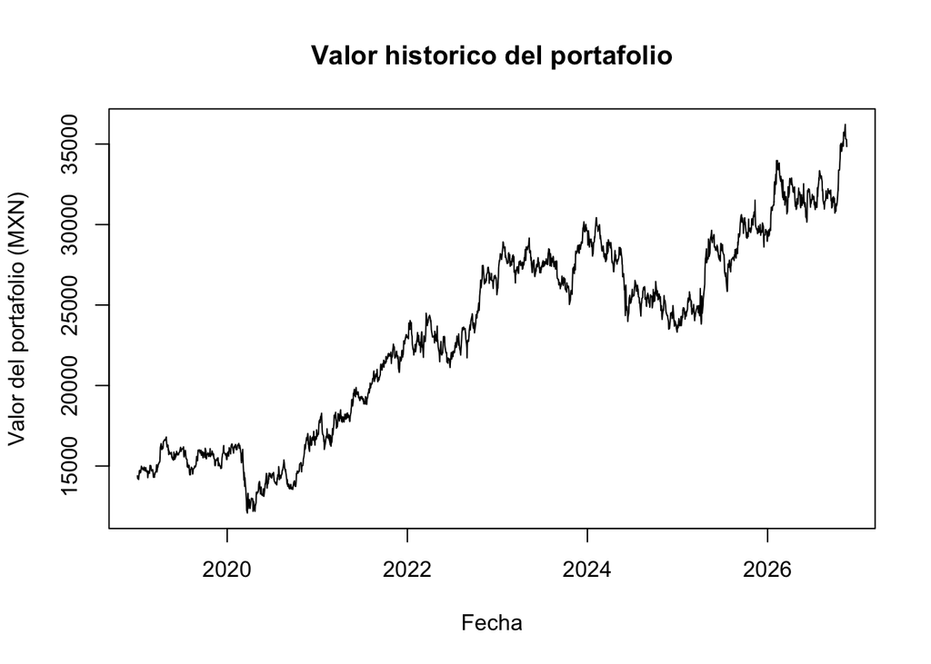

```r
Porta_Hist <- as.numeric(P_hist %*% numero)
plot(index(precios_comunes), Porta_Hist, type="l",
     main="Valor historico del portafolio",
     xlab="Fecha", ylab="Valor del portafolio (MXN)")
```

Calcular la pérdida diaria y comparar y ver cuantas veces ha excedido esa pérdida el VaR

```r
PL_real <- diff(Porta_Hist)
# Primer acercamiento ilustrativo: el VaR fijo se compara con perdidas historicas
sum(PL_real<VaR99)
```

```
## [1] 2
```

```r
mean(PL_real<VaR99)
```

```
## [1] 0.001010101
```

Segudno acercamiento: un VaR diario para muchos días

```r
ventana <- 250*2
dias_test <- 250*2

if (nrow(P_hist) < ventana + dias_test + 1) {
  stop("No hay suficientes observaciones para las ventanas elegidas.")
}

VaR_back <- numeric(dias_test)
PL_back <- numeric(dias_test)
fechas_back <- as.Date(rep(NA, dias_test))

for (i in 1:dias_test) {

  # Índice del día en que hacemos el pronóstico, al cierre.
  t <- nrow(P_hist) - dias_test - 1 + i

  # Rendimientos disponibles hasta el cierre de t.
  # R_hist[k, ] es el rendimiento de P_hist[k, ] a P_hist[k+1, ].
  R_ventana <- R_hist[(t - ventana):(t - 1), ]

  # Precios y valor del portafolio al cierre de t.
  S0_t <- as.numeric(P_hist[t, ])
  V0_t <- sum(numero * S0_t)

  # Simulación histórica para el día t+1.
  S_sim <- sweep(exp(R_ventana), 2, S0_t, "*")
  V_sim <- as.numeric(S_sim %*% numero)
  PL_sim <- V_sim - V0_t

  # Cuantil negativo: misma convención que VaR99.
  VaR_back[i] <- as.numeric(quantile(PL_sim, probs = 1 - confianza))

  # P&L realmente observado de t a t+1.
  PL_back[i] <- Porta_Hist[t + 1] - Porta_Hist[t]
  fechas_back[i] <- as.Date(index(precios)[t + 1])
}
```

```r
excede <- ifelse(PL_back < VaR_back, 1, 0)

resultados_back <- data.frame(
  fecha = fechas_back,
  VaR_pronosticado = VaR_back,
  PL_real = PL_back,
  excepcion = excede
)

head(resultados_back)
```

```
##        fecha VaR_pronosticado     PL_real excepcion
## 1 2024-11-19        -688.8725 -220.388508         0
## 2 2024-11-20        -681.2863   -2.958965         0
## 3 2024-11-21        -683.0797   11.602306         0
## 4 2024-11-22        -685.1199 -152.909088         0
## 5 2024-11-25        -677.4979 -229.074669         0
## 6 2024-11-26        -670.5201 -479.135895         0
```

```r
n_excepciones <- sum(excede)
tasa_excepciones <- mean(excede)
excepciones_esperadas <- dias_test * (1 - confianza)
```

```r
data.frame(
  Excepciones_observadas=n_excepciones,
  Excepciones_esperadas=excepciones_esperadas,
  Tasa_observada=tasa_excepciones,
  Tasa_esperada=1-confianza
)
```

```
##   Excepciones_observadas Excepciones_esperadas Tasa_observada Tasa_esperada
## 1                      6                     5          0.012          0.01
```